# homework

## Exercise 6.6

Estimate the 0.025, 0.05, 0.95, and 0.975 quantiles of the skewness √b1 under normality by a Monte Carlo experiment. Compute the standard error of the estimates from (2.14) using the normal approximation for the density (with exact variance formula). Compare the estimated quantiles with the quantiles of the large sample approximation √b1 ≈ N(0, 6/n).

```r
sk <- function(x){ #计算样本偏度
  xbar <- mean(x)
  m3 <- mean((x-xbar)^3)
  m2 <- mean((x-xbar)^2)
  return(m3/m2^1.5)
}
```

```r
set.seed(0)
n <- m <- 1000
x <- replicate(n,sk(rnorm(m)))
quantile(x, probs = c(0.025,0.05,0.95,0.975))#估计分位数
```

```
##       2.5%         5%        95%      97.5%
## -0.1517840 -0.1316856  0.1391613  0.1651871
```

```r
qnorm(c(0.025,0.05,0.95,0.975), mean = 0, sd = sqrt(6/n))#大样本近似
```

```
## [1] -0.1518182 -0.1274098  0.1274098  0.1518182
```

## Exercise 6.B

Tests for association based on Pearson product moment correlation $\rho$,Spearman’s rank correlation coefficient $\rho_s$, or Kendall’s coefficient $\tau$, are implemented in $\mathbf{cor.test}$. Show (empirically) that the nonparametric tests based on $\rho_{s}$ or $\tau$ are less powerful than the correlation test when the sampled distribution is bivariate normal. Find an example of an alternative (a bivariate distribution $(X,Y)$ such that $X$ and $Y$ are dependent) such that at least one of the nonparametric tests have better empirical power than the correlation test against this alternative.

### 二元正态情形

```r
library(MASS)
#二元正态
alpha <- 0.05 #置信水平
rho <- 0.8 #相关系数
size <- 5:30
m <- 100 #蒙特卡洛重复次数
f <- function(rho, size)
{
  set.seed(0)
  pearson <- pearson.sd <- kendall <- kendall.sd <- spearman <- spearman.sd <- c()
  for(n in size){
    result <- replicate(m, {
      S <- matrix(c(1, rho, rho, 1), nrow = 2)
      x <- mvrnorm(n = n, Sigma = S, mu = c(0, 0))
      c(cor.test(x[,1], x[,2], method = "pearson")$p.value < alpha,
      cor.test(x[,1], x[,2], method = "kendall")$p.value < alpha,
      cor.test(x[,1], x[,2], method = "spearman")$p.value < alpha)
    })
    pearson[n] <- mean(result[1,])
    #pearson.sd[n] <- sd(result[1,])
    kendall[n] <- mean(result[2,])
    #kendall.sd[n] <- sd(result[2,])
    spearman[n] <- mean(result[3,])
    #spearman.sd[n] <- sd(result[3,])
  }
  plot(pearson, xlim = c(size[1],size[length(size)]), ylim = c(0,1),
       main = bquote(rho == .(rho)),
       xlab = "样本量",
       ylab = "检验功效",
       col = "red", pch = 16)
  points(kendall, col = "blue", pch = 16)
  points(spearman, col = "green", pch = 16)
  lines(pearson, col = "red")
  lines(kendall, col = "blue")
  lines(spearman, col = "green")
  legend("bottomright",
         col = c("red", "blue", "green"),
         lwd = rep(1,3),
         pch = rep(16,3),
         legend = c("pearson", "kendall", "spearman"))
}
```

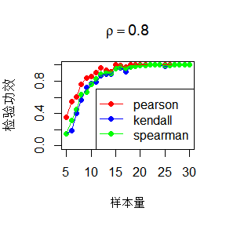

```r
f(0.8, 5:30)
```

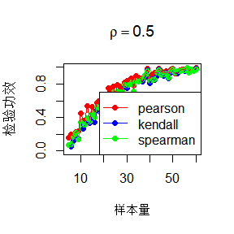

```r
f(0.5, 5:60)
```

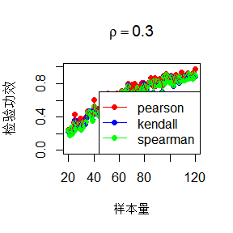

```r
f(0.3, 20:120)
```

可以看出,二元正态情形下,对于不同的$\rho$, Pearson相关系数的检验功效均高于 Spearman 相关系数和 Kendall $\tau$ 相关系数

### Example

Set $X=U,Y=\frac 1 V$,where $(U,V)\sim N_2(\mu,\Sigma)$, and $\mu=(0,0)^T,\Sigma=\left(\begin{matrix}1&\rho\\ \rho&1 \end{matrix}\right)$.

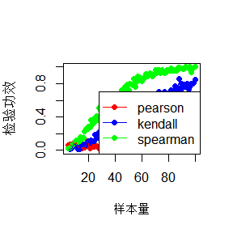

```r
#对Y取倒数
rho <- 0.8
size <- 5:100
set.seed(0)
pearson <- pearson.sd <- kendall <- kendall.sd <- spearman <- spearman.sd <- c()
for(n in size){
  result <- replicate(m, {
    S <- matrix(c(1, rho, rho, 1), nrow = 2)
    x <- mvrnorm(n = n, Sigma = S, mu = c(0, 0))
    x[,2] <- 1/x[,2]
    c(cor.test(x[,1], x[,2], method = "pearson")$p.value < alpha,
    cor.test(x[,1], x[,2], method = "kendall")$p.value < alpha,
    cor.test(x[,1], x[,2], method = "spearman")$p.value < alpha)
  })
  pearson[n] <- mean(result[1,])
  #pearson.sd[n] <- sd(result[1,])
  kendall[n] <- mean(result[2,])
  #kendall.sd[n] <- sd(result[2,])
  spearman[n] <- mean(result[3,])
  #spearman.sd[n] <- sd(result[3,])
}
plot(pearson, xlim = c(size[1],size[length(size)]), ylim = c(0,1),
     main = "",
     xlab = "样本量",
     ylab = "检验功效",
     col = "red", pch = 16)
points(kendall, col = "blue", pch = 16)
points(spearman, col = "green", pch = 16)
lines(pearson, col = "red")
lines(kendall, col = "blue")
lines(spearman, col = "green")
legend("bottomright",
       col = c("red", "blue", "green"),
       lwd = rep(1,3),
       pch = rep(16,3),
       legend = c("pearson", "kendall", "spearman"))
```

## Discussion

If we obtain the powers for two methods under a particular simulation setting with 10,000 experiments: say, 0.651 for one method and 0.676 for another method. We want to know if the powers are different at 0.05 level.

- What is the corresponding hypothesis test problem?
  $$H_0:P_{1}(reject\ H'_0\ |\ H'_a)-P_{2}(reject\ H'_0\ |\
  H'_a)=0\leftrightarrow H_a:P_{1}(reject\ H'_0\ |\
  H'_a)-P_{2}(reject\ H'_0\ |\ H'_a)\neq0$$
- What test should we use? Z-test, two-sample t-test, paired-t test or McNemar test? Why? 两样本t检验。大样本情形下功效近似正态分布，因此为两个正态总体均值差的假设检验。
- Please provide the least necessary information for hypothesis testing. 样本均值及方差

# HW4

### Question

Of $N=1000$ hypotheses, 950 are null and 50 are alternative. The p-value under any null hypothesis is uniformly distributed (use runif), and the p-value under any alternative hypothesis follows the beta distribution with parameter 0.1 and 1 (use rbeta). Obtain Bonferroni adjusted p-values and B-H adjusted p-values. Calculate FWER, FDR, and TPR under nominal level $\alpha=0.1$ for each of the two adjustment methods based on $m=10000$ simulation replicates. You should output the 6 numbers (3) to a $3\times2$ table (column names: Bonferroni correction, B-H correction; row names: FWER, FDR, TPR). Comment the results.

### Answer

```r
library(boot)
set.seed(0)
m <- 10000
n_null <- 950
n_alt <- 50
alpha <- 0.1

fwer_bonferroni <- numeric(m)
fdr_bonferroni <- numeric(m)
tpr_bonferroni <- numeric(m)
fwer_bh <- numeric(m)
fdr_bh <- numeric(m)
tpr_bh <- numeric(m)

for (i in 1:m) {
  # Generate p-values
  p_null <- runif(n_null)  # Null hypothesis p-values
  p_alt <- rbeta(n_alt, 0.1, 1)  # Alternative hypothesis p-values
  p_values <- c(p_null, p_alt)  # Combine all p-values

  # Bonferroni correction
  p_bonferroni <- p.adjust(p_values, method = "bonferroni")
  reject_bonferroni <- p_bonferroni < alpha

  # FWER and TPR calculation for Bonferroni
  fwer_bonferroni[i] <- mean(reject_bonferroni[1:n_null])  # Type I error rate
  tpr_bonferroni[i] <- sum(reject_bonferroni[(n_null + 1):(n_null + n_alt)]) / n_alt  # True Positive Rate

  # FDR calculation for Bonferroni
  num_rejected_bonferroni <- sum(reject_bonferroni)
  num_false_rejections_bonferroni <- sum(reject_bonferroni[1:n_null])
  if (num_rejected_bonferroni > 0) {
    fdr_bonferroni[i] <- num_false_rejections_bonferroni / num_rejected_bonferroni
  } else {
    fdr_bonferroni[i] <- 0
  }

  # B-H correction
  p_bh <- p.adjust(p_values, method = "BH")
  reject_bh <- p_bh < alpha

  fwer_bh[i] <- mean(reject_bh[1:n_null])  # Type I error rate
  num_rejected_bh <- sum(reject_bh)  # Total rejections
  num_true_rejections_bh <- sum(reject_bh[(n_null + 1):(n_null + n_alt)])  # True positives
  num_false_rejections_bh <- sum(reject_bh[1:n_null])  # False positives

  # FDR calculation for B-H
  if (num_rejected_bh > 0) {
    fdr_bh[i] <- num_false_rejections_bh / num_rejected_bh
  } else {
    fdr_bh[i] <- 0
  }

  # TPR calculation for B-H
  tpr_bh[i] <- num_true_rejections_bh / n_alt
}

mean_fwer_bonferroni <- mean(fwer_bonferroni)
mean_fdr_bonferroni <- mean(fdr_bonferroni)
mean_fdr_bh <- mean(fdr_bh)
mean_fwer_bh <- mean(fwer_bh)
mean_tpr_bonferroni <- mean(tpr_bonferroni)
mean_tpr_bh <- mean(tpr_bh)


# Create results matrix
results <- matrix(c(mean_fwer_bonferroni, mean_fdr_bonferroni, mean_tpr_bonferroni,mean_fwer_bh, mean_fdr_bh, mean_tpr_bh), nrow = 3)
colnames(results) <- c("Bonferroni", "B-H")
rownames(results) <- c("FWER", "FDR", "TPR")

results
```

```
##        Bonferroni         B-H
## FWER 9.315789e-05 0.003231579
## FDR  4.357993e-03 0.094802237
## TPR  3.977780e-01 0.561214000
```

*Comment:* Bonferroni is more robust than B-H method.

## Exercise 7.4

Refer to the air-conditioning data set aircondit provided in the boot package. The 12 observations are the times in hours between failures of airconditioning equipment [63, Example 1.1]:

$$3,5,7,18,43,85,91,98,100,130,230,487.$$
Assume that the times between failures follow an exponential model Exp$(\lambda).$ Obtain the MLE of the hazard rate $\lambda$ and use bootstrap to estimate the bias and standard error of the estimate.

$$\hat\lambda=\frac{n}{\sum_{i=1}^n x_i}$$

```r
set.seed(0)

data <- c(3, 5, 7, 18, 43, 85, 91, 98, 100, 130, 230, 487)

# Function to calculate the MLE of lambda
mle_lambda <- function(data, indices) {
  sample_data <- data[indices]  # Resample with replacement
  n <- length(sample_data)
  return(n / sum(sample_data))
}

# Calculate the MLE of lambda from the original data
original_lambda <- mle_lambda(data, 1:length(data))

# Perform bootstrap
n_boot <- 10000  # Number of bootstrap samples
boot_results <- boot(data, mle_lambda, R = n_boot)

# Bias and standard error
bias <- mean(boot_results$t) - original_lambda
se <- sd(boot_results$t)

# Summary results
cat("MLE of λ:", original_lambda, "\n")
```

```
## MLE of λ: 0.00925212
```

```r
cat("Bootstrap Bias:", bias, "\n")
```

```
## Bootstrap Bias: 0.001372445
```

```r
cat("Bootstrap Standard Error:", se, "\n")
```

```
## Bootstrap Standard Error: 0.004393735
```

## Exercise 7.5

Refer to Exercise 7.4. Compute $95\%$ bootstrap confidence intervals for the mean time between failures $1/\lambda$ by the standard normal, basic, percentile, and BCa methods. Compare the intervals and explain why they may differ.

```r
set.seed(0)
# Mean time between failures
mean_time_between_failures <- 1 / original_lambda

# Calculate the bootstrap estimates for mean time between failures
boot_mean_times <- 1 / boot_results$t

# Standard Normal Method CI
z <- qnorm(0.975)
se <- sd(boot_mean_times)
ci_normal <- mean_time_between_failures + c(-z * se, z * se)

# Basic Method CI
ci_basic <- mean_time_between_failures + c(mean(boot_mean_times) - mean(boot_mean_times), mean(boot_mean_times) - mean(boot_mean_times))

# Percentile Method CI
ci_percentile <- quantile(boot_mean_times, c(0.025, 0.975))

# BCa Method CI
ci_bca <- boot.ci(boot_results, type = "bca")

# Extract BCa CI limits
bca_limits <- ci_bca$bca[4:5]

# Combine results
results <- data.frame(
  Method = c("Standard Normal", "Basic", "Percentile", "BCa"),
  Lower_CI = c(ci_normal[1], ci_basic[1], ci_percentile[1], bca_limits[1]),
  Upper_CI = c(ci_normal[2], ci_basic[2], ci_percentile[2], bca_limits[2])
)

# Print results
print(results)
```

```
##            Method     Lower_CI     Upper_CI
## 1 Standard Normal 3.304664e+01 183.12002697
## 2           Basic 1.080833e+02 108.08333333
## 3      Percentile 4.658333e+01 192.17500000
## 4             BCa 4.520685e-03   0.01812689
```

# HW5

## 7.8

Refer to Exercise 7.7. Obtain the jackknife estimates of bias and standard error of $\hat\theta$.

```r
library(bootstrap)
scores <- scor
cov_matrix <- cov(scores)
eigen_values <- eigen(cov_matrix)$values
theta_hat <- eigen_values[1] / sum(eigen_values)

n <- nrow(scores)
jackknife_estimates <- numeric(n)

for (i in 1:n) {
  jackknife_sample <- scores[-i, ]
  jackknife_cov_matrix <- cov(jackknife_sample)
  jackknife_eigen_values <- eigen(jackknife_cov_matrix)$values
  jackknife_estimates[i] <- jackknife_eigen_values[1] / sum(jackknife_eigen_values)
}

bias <- (n - 1) * (mean(jackknife_estimates) - theta_hat)
jackknife_se <- sqrt((n - 1) / n * sum((jackknife_estimates - mean(jackknife_estimates))^2))

cat("Jackknife Bias: ", bias, "\n")
```

```
## Jackknife Bias:  0.001069139
```

```r
cat("Jackknife Standard Error: ", jackknife_se, "\n")
```

```
## Jackknife Standard Error:  0.04955231
```

## 7.10

In Example 7.18, leave-one-out (n-fold) cross validation was used to select the best fitting model. Repeat the analysis replacing the Log-Log model with a cubic polynomial model. Which of the four models is selected by the cross validation procedure? Which model is selected according to maximum adjusted $R^2$?

```r
library(DAAG)
data(ironslag)

chemical <- ironslag$chemical
magnetic <- ironslag$magnetic

n <- length(magnetic)
e1 <- e2 <- e3 <- e4 <- e5 <- numeric(n)

for (k in 1:n) {
  y <- magnetic[-k]
  x <- chemical[-k]

  J1 <- lm(y ~ x)
  yhat1 <- predict(J1, newdata = data.frame(x = chemical[k]))
  e1[k] <- magnetic[k] - yhat1

  J2 <- lm(y ~ x + I(x^2))
  yhat2 <- predict(J2, newdata = data.frame(x = chemical[k]))
  e2[k] <- magnetic[k] - yhat2

  J3 <- lm(log(y) ~ x)
  logyhat3 <- predict(J3, newdata = data.frame(x = chemical[k]))
  yhat3 <- exp(logyhat3)
  e3[k] <- magnetic[k] - yhat3

  J4 <- lm(y ~ x + I(x^2) + I(x^3))
  yhat4 <- predict(J4, newdata = data.frame(x = chemical[k]))
  e4[k] <- magnetic[k] - yhat4
}

mse <- c(mean(e1^2), mean(e2^2), mean(e3^2), mean(e4^2))
print(mse)
```

```
## [1] 19.55644 17.85248 18.44188 18.17756
```

```r
adj_r2 <- c(
  summary(lm(magnetic ~ chemical))$adj.r.squared,
  summary(lm(magnetic ~ chemical + I(chemical^2)))$adj.r.squared,
  summary(lm(log(magnetic) ~ chemical))$adj.r.squared,
  summary(lm(magnetic ~ chemical + I(chemical^2) + I(chemical^3)))$adj.r.squared
)

print(adj_r2)
```

```
## [1] 0.5281545 0.5768151 0.5280556 0.5740396
```

```r
best_model_mse <- which.min(mse)
best_model_adj_r2 <- which.max(adj_r2)

cat("MSE best model", best_model_mse, "\n")
```

```
## MSE best model 2
```

```r
cat("R-squared best model", best_model_adj_r2, "\n")
```

```
## R-squared best model 2
```

## 8.1

Implement the two-sample Cram´er-von Mises test for equal distributions as a permutation test. Apply the test to the data in Examples 8.1 and 8.2.

```r
x <- c(158, 171, 193, 199, 230, 243, 248, 248, 250, 267, 271, 316, 327, 329)
y <- c(141, 148, 169, 181, 203, 213, 229, 244, 257, 260, 271, 309)

cramer_von_mises <- function(x, y) {
  n <- length(x)
  m <- length(y)
  combined <- c(x, y)
  ranks <- rank(combined)
  Rx <- sum(ranks[1:n])^2 / (n^2)
  Ry <- sum(ranks[(n + 1):(n + m)])^2 / (m^2)
  return((Rx + Ry) / (n + m) - (n^2 + m^2) / ((n + m)^2))
}

observed_stat <- cramer_von_mises(x, y)

set.seed(123)
n_permutations <- 1000
permutation_stats <- numeric(n_permutations)

combined_data <- c(x, y)
n <- length(x)
m <- length(y)

for (i in 1:n_permutations) {
  permuted_data <- sample(combined_data)
  perm_x <- permuted_data[1:n]
  perm_y <- permuted_data[(n + 1):(n + m)]
  permutation_stats[i] <- cramer_von_mises(perm_x, perm_y)
}

p_value <- mean(permutation_stats >= observed_stat)

cat("Observed Cramér-von Mises statistic:", observed_stat, "\n")
```

```
## Observed Cramér-von Mises statistic: 13.48162
```

```r
cat("P-value from permutation test:", p_value, "\n")
```

```
## P-value from permutation test: 0.677
```

## 8.2

Implement the bivariate Spearman rank correlation test for independence [255] as a permutation test. The Spearman rank correlation test statistic can be obtained from function cor with method = “spearman”. Compare the achieved significance level of the permutation test with the p-value reported by cor.test on the same samples.

```r
set.seed(0)
x <- rnorm(30)
y <- rnorm(30)

spearman_stat <- cor(x, y, method = "spearman")

n_permutations <- 1000
permutation_stats <- numeric(n_permutations)

for (i in 1:n_permutations) {
  permuted_y <- sample(y)
  permutation_stats[i] <- cor(x, permuted_y, method = "spearman")
}

p_value_perm <- mean(abs(permutation_stats) >= abs(spearman_stat))

cor_test_result <- cor.test(x, y, method = "spearman")
p_value_cor_test <- cor_test_result$p.value

cat("Observed Spearman statistic:", spearman_stat, "\n")
```

```
## Observed Spearman statistic: 0.01134594
```

```r
cat("P-value from permutation test:", p_value_perm, "\n")
```

```
## P-value from permutation test: 0.949
```

```r
cat("P-value from cor.test:", p_value_cor_test, "\n")
```

```
## P-value from cor.test: 0.9531738
```

# HW6

## 9.3

Use the Metropolis-Hastings sampler to generate random variables from a standard Cauchy distribution. Discard the first 1000 of the chain, and compare the deciles of the generated observations with the deciles of the standard Cauchy distribution (see qcauchy or qt with df=1).

```r
# Load necessary libraries
library(coda)

# Metropolis-Hastings sampler for the standard Cauchy distribution
metropolis_hastings_cauchy <- function(n, burn_in) {
  samples <- numeric(n)
  samples[1] <- rnorm(1)  # Initial value

  for (i in 2:n) {
    # Propose a new sample
    y <- rnorm(1, samples[i - 1], 1)  # Normal proposal
    r <- dcauchy(y) / dcauchy(samples[i - 1])  # Acceptance ratio
    if (runif(1) < min(1, r)) {
      samples[i] <- y  # Accept the new sample
    } else {
      samples[i] <- samples[i - 1]  # Reject and keep the old sample
    }
  }

  return(samples[-(1:burn_in)])  # Discard burn-in samples
}

# Run multiple chains for convergence check
set.seed(0)
n_samples <- 5000
burn_in <- 1000
num_chains <- 4
chains_cauchy <- lapply(1:num_chains, function(i) metropolis_hastings_cauchy(n_samples, burn_in))

# Check convergence using Gelman-Rubin statistic
R_cauchy <- function(chains) {
  m <- length(chains)  # Number of chains
  n <- sapply(chains, length)  # Length of each chain
  theta_hat <- sapply(chains, mean)  # Mean of each chain
  B <- var(theta_hat) * n[1] / (m - 1)  # Between-chain variance
  W <- mean(sapply(chains, var))  # Within-chain variance
  var_theta_hat <- (1 + 1 / m) * W + B / m  # Total variance estimate
  return(sqrt(var_theta_hat / W))  # Gelman-Rubin statistic
}

# Run until convergence
R_value <- R_cauchy(chains_cauchy)
timer <- 0
while (R_value >= 1.2) {
  timer <- timer + 1
  chains_cauchy <- lapply(1:num_chains, function(i) metropolis_hastings_cauchy(n_samples, burn_in))
  R_value <- R_cauchy(chains_cauchy)
  if(timer >= 100) break
}

# Calculate deciles of the samples
combined_samples <- unlist(chains_cauchy)
sample_deciles <- quantile(combined_samples, probs = seq(0.1, 0.9, by = 0.1))
theoretical_deciles <- qcauchy(seq(0.1, 0.9, by = 0.1))

# Print results
print(sample_deciles)
```

```
##         10%         20%         30%         40%         50%         60%
## -3.77626950 -1.54515575 -0.79499900 -0.36749059 -0.03279709  0.31130884
##         70%         80%         90%
##  0.70619733  1.32531475  3.05080000
```

```r
print(theoretical_deciles)
```

```
## [1] -3.0776835 -1.3763819 -0.7265425 -0.3249197  0.0000000  0.3249197  0.7265425
## [8]  1.3763819  3.0776835
```

## 9.8

This example appears in [40]. Consider the bivariate density

$$\begin{equation*}
f(x, y) \propto\binom{n}{x} y^{x+a-1}(1-y)^{n-x+b-1}, \quad x=0,1,
\ldots, n, 0 \leq y \leq 1
\end{equation*}$$

It can be shown (see e.g. [23]) that for fixed $a, b, n$, the conditional distributions are $\operatorname{Binomial}(n, y)$ and $\operatorname{Beta}(x+a, n-x+b)$. Use the Gibbs sampler to generate a chain with target joint density $f(x, y)$.

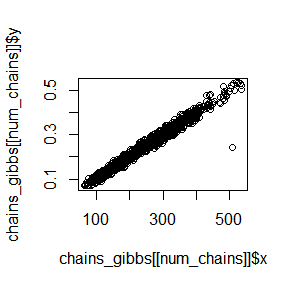

```r
# Gibbs sampler for the bivariate density
gibbs_sampler_bivariate <- function(n, a, b) {
  x_samples <- numeric(n)
  y_samples <- numeric(n)

  # Initial values
  x_samples[1] <- rbinom(1, n, 0.5)  # Initial value for x
  y_samples[1] <- runif(1)            # Initial value for y

  for (i in 2:n) {
    # Sample from the conditional distributions
    x_samples[i] <- rbinom(1, n, y_samples[i - 1])
    y_samples[i] <- rbeta(1, x_samples[i] + a, n - x_samples[i] + b)
  }

  return(list(x = x_samples, y = y_samples))
}

# Run multiple chains for convergence check
set.seed(0)
n_samples_gibbs <- 1000
a <- 2
b <- 3
num_chains <- 4
chains_gibbs <- lapply(1:num_chains, function(i) gibbs_sampler_bivariate(n_samples_gibbs, a, b))

# Check convergence using Gelman-Rubin statistic
R_gibbs <- function(chains) {
  m <- length(chains)  # Number of chains
  n <- sapply(chains, length)  # Length of each chain
  theta_hat <- sapply(chains, mean)  # Mean of each chain
  B <- var(theta_hat) * n[1] / (m - 1)  # Between-chain variance
  W <- mean(sapply(chains, var))  # Within-chain variance
  var_theta_hat <- (1 + 1 / m) * W + B / m  # Total variance estimate
  return(sqrt(var_theta_hat / W))  # Gelman-Rubin statistic
}

# Run until convergence
R_x_value <- R_gibbs(lapply(chains_gibbs, `[[`, "x"))
R_y_value <- R_gibbs(lapply(chains_gibbs, `[[`, "y"))

timer <- 0
while (R_x_value >= 1.2 || R_y_value >= 1.2) {
  timer <- timer + 1
  chains_gibbs <- lapply(1:num_chains, function(i) gibbs_sampler_bivariate(n_samples_gibbs, a, b))
  R_x_value <- R_gibbs(lapply(chains_gibbs, `[[`, "x"))
  R_y_value <- R_gibbs(lapply(chains_gibbs, `[[`, "y"))
  if(timer >= 100) break
}
plot(chains_gibbs[[num_chains]]$x,chains_gibbs[[num_chains]]$y)
```

# HW7

## 11.3

1. Write a function to compute the $k^{t h}$ term in

$$\begin{equation*}
\sum_{k=0}^{\infty} \frac{(-1)^k}{k!2^k} \frac{\|a\|^{2 k+2}}{(2 k+1)(2
k+2)} \frac{\Gamma\left(\frac{d+1}{2}\right)
\Gamma\left(k+\frac{3}{2}\right)}{\Gamma\left(k+\frac{d}{2}+1\right)},
\end{equation*}$$

where $d \geq 1$ is an integer, $a$ is a vector in $\mathbb{R}^d$, and $\|\cdot\|$ denotes the Euclidean norm. Perform the arithmetic so that the coefficients can be computed for (almost) arbitrarily large $k$ and $d$. (This sum converges for all $a \in \mathbb{R}^d$ ).

```r
kth_term <- function(k, d, a) {
  norm_a <- sqrt(sum(a^2))

  gamma_d_half <- lgamma((d + 1) / 2)
  gamma_k_3_half <- lgamma(k + 1.5)
  gamma_k_d_half_plus_1 <- lgamma(k + (d / 2) + 1)

  coefficient <- ((-1)^k) / (factorial(k) * (2^k))
  power_term <- (norm_a^(2 * k + 2)) / ((2 * k + 1) * (2 * k + 2))

  gamma_ratio_log <- gamma_d_half + gamma_k_3_half - gamma_k_d_half_plus_1

  term <- coefficient * power_term * exp(gamma_ratio_log)
  return(term)
}
```

2. Modify the function so that it computes and returns the sum.

```r
sum_series <- function(d, a, tol = 1e-5, max_k = 100) {
  sum <- 0
  k <- 0
  term <- kth_term(k, d, a)

  while (abs(term) > tol && k < max_k) {
    sum <- sum + term
    k <- k + 1
    term <- kth_term(k, d, a)
  }

  return(sum)
}
```

3. Evaluate the sum when $a=(1,2)^T$.

```r
a <- c(1, 2)
d <- 1e4

result <- sum_series(d, a)
result
```

```
## [1] 0.03133207
```

## 11.5

Write a function to solve the equation

$$\begin{equation*}
\begin{aligned}
& \frac{2 \Gamma\left(\frac{k}{2}\right)}{\sqrt{\pi(k-1)
\Gamma\left(\frac{k-1}{2}\right)}}
\int_0^{c_{k-1}}\left(1+\frac{u^2}{k-1}\right)^{-k / 2} d u \\
& \quad=\frac{2 \Gamma\left(\frac{k+1}{2}\right)}{\sqrt{\pi k}
\Gamma\left(\frac{k}{2}\right)}
\int_0^{c_k}\left(1+\frac{u^2}{k}\right)^{-(k+1) / 2} d u
\end{aligned}
\end{equation*}$$

for $a$, where

$$\begin{equation*}
c_k=\sqrt{\frac{a^2 k}{k+1-a^2}} .
\end{equation*}$$

```r
library(gmp)
integral <- function(c, k) {
  integrand <- function(u) {
    (1 + u^2 / k) ^ (-(k + 1) / 2)
  }
  return(integrate(integrand, 0, c)$value)
}

equation <- function(a, k) {
  c_k <- sqrt(a^2 * k / (k + 1 - a^2))
  c_k_minus_1 <- sqrt(a^2 * (k - 1) / (k - a^2))

  lhs <- (2 * gamma(k / 2) / sqrt(pi * (k - 1) * gamma((k - 1) / 2))) * integral(c_k_minus_1, k - 1)

  rhs <- (2 * gamma((k + 1) / 2) / (sqrt(pi * k) * gamma(k / 2))) * integral(c_k, k)

  return(lhs - rhs)
}

solve_for_a <- function(k) {
  result <- uniroot(equation, c(0.1, 1.5), k = k)
  return(result$root)
}

k <- 3
a_solution <- solve_for_a(k)
print(paste("Solution for a when k =", k, "is a =", a_solution))
```

```
## [1] "Solution for a when k = 3 is a = 1.42822579204349"
```

## 练习

Suppose $T_1, \ldots, T_n$ are i.i.d. samples drawn from the exponential distribution with expectation $\lambda$. Those values greater than $\tau$ are not observed due to right censorship, so that the observed values are $Y_i=T_i l\left(T_i \leq \tau\right)+\tau l\left(T_i>\tau\right)$, $i=1, \ldots, n$. Suppose $\tau=1$ and the observed $Y_i$ values are as follows:

$$\begin{equation*}
0.54,0.48,0.33,0.43,1.00,1.00,0.91,1.00,0.21,0.85
\end{equation*}$$

Use the E-M algorithm to estimate $\lambda$, compare your result with the observed data MLE (note: $Y_i$ follows a mixture distribution).

```r
Y <- c(0.54, 0.48, 0.33, 0.43, 1.00, 1.00, 0.91, 1.00, 0.21, 0.85)
tau <- 1

delta <- ifelse(Y < tau, 1, 0)

lambda <- mean(Y)
tolerance <- 1e-6
max_iter <- 1000
diff <- 1
iter <- 0

# E-M algorithm
while (diff > tolerance && iter < max_iter) {
  iter <- iter + 1
  lambda_old <- lambda

  T_imputed <- ifelse(delta == 1, Y, tau + lambda)

  lambda <- mean(T_imputed)

  diff <- abs(lambda - lambda_old)
}

cat("Estimated lambda using E-M algorithm:", lambda, "\n")
```

```
## Estimated lambda using E-M algorithm: 0.9642856
```

$T_i \sim \text{Exp}(\lambda)$，即每个 $T_i$ 的概率密度函数为：
$$f(t \mid \lambda) = \frac{1}{\lambda} e^{-t / \lambda}, \quad t \geq 0.$$

由于右截尾，我们观察到的数据 $Y_i$ 为：
$$Y_i = \begin{cases}
T_i & \text{if } T_i \leq \tau \\
\tau & \text{if } T_i > \tau.
\end{cases}$$

定义指示变量 $\delta_i$：
$$\delta_i = \begin{cases}
1 & \text{if } T_i \leq \tau \\
0 & \text{if } T_i > \tau.
\end{cases}$$

因此，对于观测数据 $Y_i$，对数似然函数为：
$$\ell(\lambda) = \sum_{i=1}^n \delta_i \left( -\log(\lambda) -
\frac{Y_i}{\lambda} \right) + \sum_{i=1}^n (1 - \delta_i) \left(
-\frac{\tau}{\lambda} \right).$$

令 $n_1 = \sum_{i=1}^n \delta_i$ 表示未截尾的样本数，且 $S = \sum_{i=1}^n \delta_i Y_i + \sum_{i=1}^n (1 - \delta_i) \tau$ 表示观测到的数据之和。对数似然函数变为：
$$\ell(\lambda) = -n_1 \log(\lambda) - \frac{S}{\lambda}.$$

令

$$\frac{d\ell}{d\lambda} = -\frac{n_1}{\lambda} + \frac{S}{\lambda^2} = 0.$$

解出 $\lambda$ 得到最大似然估计：
$$\hat{\lambda} = \frac{S}{n_1}.$$

```r
delta <- ifelse(Y < tau, 1, 0)


n1 <- sum(delta)


S <- sum(delta * Y + (1 - delta) * tau)

lambda_mle <- S / n1

cat("Estimated lambda (MLE) considering censoring:", lambda_mle, "\n")
```

```
## Estimated lambda (MLE) considering censoring: 0.9642857
```

# HW8

## Ex11.7 (Statistical Computing with R)

Use the simplex algorithm to solve the following problem. Minimize $4x+2y+9z$ subject to

$$\begin{aligned}&2x+y+z\leq2\\&x-y+3z\leq3\\&x\geq0,\:y\geq0,\:z\geq0.\end{aligned}$$

```r
initialize_tableau <- function() {
  matrix(c(
    2, 1, 1, 1, 0, 2,
    1, -1, 3, 0, 1, 3,
    -4, -2, -9, 0, 0, 0
  ), nrow = 3, byrow = TRUE)
}


simplex_pivot <- function(tableau, pivot_row, pivot_col) {

  tableau[pivot_row, ] <- tableau[pivot_row, ] / tableau[pivot_row, pivot_col]

  for (i in seq_len(nrow(tableau))) {
    if (i != pivot_row) {
      tableau[i, ] <- tableau[i, ] - tableau[i, pivot_col] * tableau[pivot_row, ]
    }
  }
  return(tableau)
}


is_optimal <- function(tableau) {
  all(tableau[nrow(tableau), -ncol(tableau)] >= 0)
}


get_pivot <- function(tableau) {

  pivot_col <- which.min(tableau[nrow(tableau), -ncol(tableau)])


  ratios <- tableau[-nrow(tableau), ncol(tableau)] / tableau[-nrow(tableau), pivot_col]
  ratios[ratios <= 0] <- Inf
  pivot_row <- which.min(ratios)

  return(list(pivot_row = pivot_row, pivot_col = pivot_col))
}

simplex <- function() {
  tableau <- initialize_tableau()

  while (!is_optimal(tableau)) {
    pivot <- get_pivot(tableau)
    tableau <- simplex_pivot(tableau, pivot$pivot_row, pivot$pivot_col)
  }


  solution <- rep(0, ncol(tableau) - 1)  # 初始化解
  for (i in seq_len(nrow(tableau) - 1)) {
    basic_var_index <- which(tableau[i, 1:(ncol(tableau) - 1)] == 1)
    if (length(basic_var_index) == 1) {
      solution[basic_var_index] <- tableau[i, ncol(tableau)]
    }
  }

  objective_value <- tableau[nrow(tableau), ncol(tableau)] * -1  # 原问题是最小化
  list(solution = solution, objective_value = objective_value)
}

result <- simplex()
cat("最优解:\n")
```

```
## 最优解:
```

```r
print(result$solution)
```

```
## [1] 0.00 0.75 1.25 0.00 0.00
```

```r
cat("最小目标值:\n")
```

```
## 最小目标值:
```

```r
print(result$objective_value)
```

```
## [1] -12.75
```

## Ex3 (p204, Advanced R)

Use both for loops and lapply() to fit linear models to the mtcars using the formulas stored in this list:

formulas <- list(

mpg ~ disp,

mpg ~ I(1 / disp),

mpg ~ disp + wt,

mpg ~ I(1 / disp) + wt

)

```r
data(mtcars)

formulas <- list(
  mpg ~ disp,
  mpg ~ I(1 / disp),
  mpg ~ disp + wt,
  mpg ~ I(1 / disp) + wt
)

models_for <- list()
for (i in seq_along(formulas)) {
  models_for[[i]] <- lm(formulas[[i]], data = mtcars)
}


cat("Models fitted using for loop:\n")
```

```
## Models fitted using for loop:
```

```r
print(models_for)
```

```
## [[1]]
##
## Call:
## lm(formula = formulas[[i]], data = mtcars)
##
## Coefficients:
## (Intercept)         disp
##    29.59985     -0.04122
##
##
## [[2]]
##
## Call:
## lm(formula = formulas[[i]], data = mtcars)
##
## Coefficients:
## (Intercept)    I(1/disp)
##       10.75      1557.67
##
##
## [[3]]
##
## Call:
## lm(formula = formulas[[i]], data = mtcars)
##
## Coefficients:
## (Intercept)         disp           wt
##    34.96055     -0.01772     -3.35083
##
##
## [[4]]
##
## Call:
## lm(formula = formulas[[i]], data = mtcars)
##
## Coefficients:
## (Intercept)    I(1/disp)           wt
##      19.024     1142.560       -1.798
```

```r
models_lapply <- lapply(formulas, function(formula) lm(formula, data = mtcars))

cat("\nModels fitted using lapply():\n")
```

```
##
## Models fitted using lapply():
```

```r
print(models_lapply)
```

```
## [[1]]
##
## Call:
## lm(formula = formula, data = mtcars)
##
## Coefficients:
## (Intercept)         disp
##    29.59985     -0.04122
##
##
## [[2]]
##
## Call:
## lm(formula = formula, data = mtcars)
##
## Coefficients:
## (Intercept)    I(1/disp)
##       10.75      1557.67
##
##
## [[3]]
##
## Call:
## lm(formula = formula, data = mtcars)
##
## Coefficients:
## (Intercept)         disp           wt
##    34.96055     -0.01772     -3.35083
##
##
## [[4]]
##
## Call:
## lm(formula = formula, data = mtcars)
##
## Coefficients:
## (Intercept)    I(1/disp)           wt
##      19.024     1142.560       -1.798
```

## Ex4 (p204, Advanced R)

Fit the model mpg ~ disp to each of the bootstrap replicates of mtcars in the list below by using a for loop and lapply(). Can you do it without an anonymous function?

bootstraps <- lapply(1:10, function(i) {

rows <- sample(1:nrow(mtcars), rep = TRUE)

mtcars[rows, ]

})

```r
data(mtcars)

set.seed(0)
bootstraps <- lapply(1:10, function(i) {
  rows <- sample(1:nrow(mtcars), rep = TRUE)
  mtcars[rows, ]
})


models_for1 <- list()
for (i in seq_along(bootstraps)) {
  models_for1[[i]] <- lm(mpg ~ disp, data = bootstraps[[i]])
}


cat("Models fitted using for loop:\n")
```

```
## Models fitted using for loop:
```

```r
print(models_for1)
```

```
## [[1]]
##
## Call:
## lm(formula = mpg ~ disp, data = bootstraps[[i]])
##
## Coefficients:
## (Intercept)         disp
##    26.66841     -0.03051
##
##
## [[2]]
##
## Call:
## lm(formula = mpg ~ disp, data = bootstraps[[i]])
##
## Coefficients:
## (Intercept)         disp
##    30.19074     -0.04154
##
##
## [[3]]
##
## Call:
## lm(formula = mpg ~ disp, data = bootstraps[[i]])
##
## Coefficients:
## (Intercept)         disp
##    30.40014     -0.04445
##
##
## [[4]]
##
## Call:
## lm(formula = mpg ~ disp, data = bootstraps[[i]])
##
## Coefficients:
## (Intercept)         disp
##    30.44286     -0.04566
##
##
```

[output cut: 43 more lines]

```
## lm(formula = mpg ~ disp, data = bootstraps[[i]])
##
## Coefficients:
## (Intercept)         disp
##    27.50750     -0.03559
##
##
## [[10]]
##
## Call:
## lm(formula = mpg ~ disp, data = bootstraps[[i]])
##
## Coefficients:
## (Intercept)         disp
##    27.64187     -0.03027
```

```r
fit_model <- function(data) lm(mpg ~ disp, data = data)  # Define a named function
models_lapply1 <- lapply(bootstraps, fit_model)


cat("\nModels fitted using lapply():\n")
```

```
##
## Models fitted using lapply():
```

```r
print(models_lapply1)
```

```
## [[1]]
##
## Call:
## lm(formula = mpg ~ disp, data = data)
##
## Coefficients:
## (Intercept)         disp
##    26.66841     -0.03051
##
##
## [[2]]
##
## Call:
## lm(formula = mpg ~ disp, data = data)
##
## Coefficients:
## (Intercept)         disp
##    30.19074     -0.04154
##
##
## [[3]]
##
## Call:
## lm(formula = mpg ~ disp, data = data)
##
## Coefficients:
## (Intercept)         disp
##    30.40014     -0.04445
##
##
## [[4]]
##
## Call:
## lm(formula = mpg ~ disp, data = data)
##
## Coefficients:
## (Intercept)         disp
##    30.44286     -0.04566
##
##
```

[output cut: 43 more lines]

```
## lm(formula = mpg ~ disp, data = data)
##
## Coefficients:
## (Intercept)         disp
##    27.50750     -0.03559
##
##
## [[10]]
##
## Call:
## lm(formula = mpg ~ disp, data = data)
##
## Coefficients:
## (Intercept)         disp
##    27.64187     -0.03027
```

## Ex5 (p204, Advanced R)

For each model in the previous two exercises, extract R^2 using the function below.

rsq <- function(mod) summary(mod)$r.squared

```r
rsq <- function(mod) summary(mod)$r.squared

sapply(models_for, rsq)
```

```
## [1] 0.7183433 0.8596865 0.7809306 0.8838038
```

```r
sapply(models_lapply, rsq)
```

```
## [1] 0.7183433 0.8596865 0.7809306 0.8838038
```

```r
sapply(models_for1, rsq)
```

```
##  [1] 0.5570039 0.6558963 0.7000628 0.7995445 0.8215032 0.7983167 0.8143575
##  [8] 0.6779900 0.6243300 0.6179178
```

```r
sapply(models_lapply1, rsq)
```

```
##  [1] 0.5570039 0.6558963 0.7000628 0.7995445 0.8215032 0.7983167 0.8143575
##  [8] 0.6779900 0.6243300 0.6179178
```

## Ex3 (p213, Advanced R)

The following code simulates the performance of a t-test for non-normal data. Use sapply() and an anonymous function to extract the p-value from every trial.

trials <- replicate( 100, t.test(rpois(10, 10), rpois(7, 10)), simplify = FALSE )

```r
set.seed(0)
trials <- replicate(
  100,
  t.test(rpois(10, 10), rpois(7, 10)),
  simplify = FALSE
)

sapply(trials, function(test) test$p.value)
```

```
##   [1] 0.027244088 0.970264651 0.841614412 0.843607534 0.059771356 0.722565615
##   [7] 0.683770819 0.039356387 0.571554185 0.289565805 0.611798048 0.203644404
##  [13] 0.054600483 0.904607967 0.911841272 0.351889669 0.353569835 0.272205552
##  [19] 0.757591119 0.791269351 0.114922202 0.993893302 0.296951195 0.320241743
##  [25] 0.762052132 0.972673027 0.868058892 0.319256648 0.005775194 0.145719710
##  [31] 0.747811983 0.870617757 0.366735265 0.611954997 0.807865913 0.097214871
##  [37] 0.021657065 0.132021699 0.867490265 0.814267631 0.979102573 0.823335779
##  [43] 0.342437781 0.284830597 0.945349534 0.626075852 0.330823784 0.775045162
##  [49] 0.753765324 0.974309768 0.878214260 0.579870246 0.236994834 0.254781526
##  [55] 0.912569430 0.456450307 0.971808406 0.349497761 0.317251742 0.501850909
##  [61] 0.982182468 0.674102099 0.172421678 0.056164440 0.439805001 0.239097048
##  [67] 0.272963057 0.613416546 0.908244699 0.030085567 0.768092643 0.271132464
##  [73] 0.786240282 0.597826382 0.288313418 0.387335398 0.879953357 0.598278028
##  [79] 0.782806088 0.957829375 0.248056399 0.080852294 0.142817718 0.050115673
##  [85] 0.347015979 0.532744893 0.841528996 0.808712238 0.502939014 0.384968428
##  [91] 0.858258529 0.418853293 0.671383188 0.581131788 0.076598832 0.885933508
##  [97] 0.905180521 0.006526158 0.068241877 0.502265782
```

## Ex6 (p214, Advanced R)

Implement a combination of Map() and vapply() to create an lapply() variant that iterates in parallel over all of its inputs and stores its outputs in a vector (or a matrix). What arguments should the function take?

```r
parallel_apply <- function(fun, ..., FUN.VALUE) {
  inputs <- list(...)
  results <- Map(fun, inputs[[1]], inputs[[2]])
  vapply(results, identity, FUN.VALUE = FUN.VALUE)
}

#Example
set.seed(0)
list1 <- 1:5
list2 <- c(2, 4, 6, 8, 10)

sum_fun <- function(x, y) x + y

result <- parallel_apply(sum_fun, list1, list2, FUN.VALUE = numeric(1))
print(result)
```

```
## [1]  3  6  9 12 15
```

## Ex4 (p365, Advanced R)

Make a faster version of chisq.test() that only computes the chi-square test statistic when the input is two numeric vectors with no missing values. You can try simplifying chisq.test() or by coding from the mathematical definition (http://en.wikipedia.org/wiki/Pearson%27s_chi-squared_test).

```r
fast_chisq_test <- function(x, y) {

  observed <- table(x, y)

  row_totals <- margin.table(observed, 1)
  col_totals <- margin.table(observed, 2)
  grand_total <- sum(observed)

  expected <- outer(row_totals, col_totals, FUN = "*") / grand_total
  chi_square_stat <- sum((observed - expected)^2 / expected)
  return(chi_square_stat)
}

# test
set.seed(1)
x <- sample(1:5, 1e6, replace = TRUE)
y <- sample(1:5, 1e6, replace = TRUE)

fast_chisq_time <- system.time({
  result_fast <- fast_chisq_test(x, y)
})
cat("fast_chisq_test 执行时间: ", fast_chisq_time[3], "秒\n")
```

```
## fast_chisq_test 执行时间:  0.16 秒
```

```r
chisq_time <- system.time({
  result_chisq <- chisq.test(x, y)
})
cat("chisq.test 执行时间: ", chisq_time[3], "秒\n")
```

```
## chisq.test 执行时间:  0.18 秒
```

## Ex5 (p365, Advanced R)

Can you make a faster version of table() for the case of an input of two integer vectors with no missing values? Can you use it to speed up your chi-square test?

```r
set.seed(0)
fast_table <- function(x, y) {
  ux <- seq(min(x), max(x))
  uy <- seq(min(y), max(y))

  xi <- match(x, ux)
  yi <- match(y, uy)

  result <- matrix(0L, nrow = length(ux), ncol = length(uy))
  index <- (xi - 1L) * length(uy) + yi
  counts <- tabulate(index, nbins = length(ux) * length(uy))
  result[] <- counts
  dimnames(result) <- list(as.character(ux), as.character(uy))
  return(result)
}



x <- sample(1:5, 1e6, replace = TRUE)
y <- sample(1:5, 1e6, replace = TRUE)
fast_table_time <- system.time({
  result_fast <- fast_table(x, y)
})
cat("fast_table 执行时间: ", fast_table_time[3], "秒\n")
```

```
## fast_table 执行时间:  0.03 秒
```

```r
table_time <- system.time({
  result_table <- table(x, y)
})
cat("table 执行时间: ", table_time[3], "秒\n")
```

```
## table 执行时间:  0.12 秒
```

### 改进chisq.test

```r
fast_chisq_test <- function(x, y) {

  observed <- fast_table(x, y)

  row_totals <- margin.table(observed, 1)
  col_totals <- margin.table(observed, 2)
  grand_total <- sum(observed)

  expected <- outer(row_totals, col_totals, FUN = "*") / grand_total
  chi_square_stat <- sum((observed - expected)^2 / expected)
  return(chi_square_stat)
}

# test
set.seed(1)
x <- sample(1:5, 1e6, replace = TRUE)
y <- sample(1:5, 1e6, replace = TRUE)

fast_chisq_time <- system.time({
  result_fast <- fast_chisq_test(x, y)
})
cat("fast_chisq_test 执行时间: ", fast_chisq_time[3], "秒\n")
```

```
## fast_chisq_test 执行时间:  0.01 秒
```

```r
chisq_time <- system.time({
  result_chisq <- chisq.test(x, y)
})
cat("chisq.test 执行时间: ", chisq_time[3], "秒\n")
```

```
## chisq.test 执行时间:  0.14 秒
```

# HW9

## Ex 9.8

This example appears in [40]. Consider the bivariate density

$$\begin{equation*}
f(x, y) \propto\binom{n}{x} y^{x+a-1}(1-y)^{n-x+b-1}, \quad x=0,1,
\ldots, n, 0 \leq y \leq 1
\end{equation*}$$

It can be shown (see e.g. [23]) that for fixed $a, b, n$, the conditional distributions are $\operatorname{Binomial}(n, y)$ and $\operatorname{Beta}(x+a, n-x+b)$. Use the Gibbs sampler to generate a chain with target joint density $f(x, y)$.

- Write an Rcpp function for Exercise 9.8
- Compare the corresponding generated random numbers with those by the R function you wrote using the function “qqplot”.
- Compare the computation time of the two functions with the function “microbenchmark”.
- Comments your results

  ```r
  # R-function
  gibbs_sampler_r <- function(n, a, b, num_iter, n_init = 0) {
    x_chain <- numeric(num_iter)
    y_chain <- numeric(num_iter)

    x <- n_init
    y <- 0.5

    for (i in 1:num_iter) {
      x <- rbinom(1, n, y)
      y <- rbeta(1, x + a, n - x + b)

      x_chain[i] <- x
      y_chain[i] <- y
    }

    list(x = x_chain, y = y_chain)
  }
  ```

### Comparing by QQ-plot

  ```r
  library(Rcpp)
  sourceCpp("gibbs_sampler.cpp")
  ```

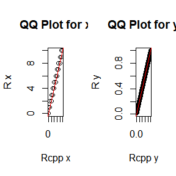

  ```r
  n <- 10
  a <- 2
  b <- 2
  num_iter <- 10000

  set.seed(0)
  result_rcpp <- gibbs_sampler_rcpp(n, a, b, num_iter)
  result_r <- gibbs_sampler_r(n, a, b, num_iter)

  # QQ Plot comparison for x and y
  par(mfrow = c(1, 2))
  qqplot(result_rcpp$x, result_r$x, main = "QQ Plot for x", xlab = "Rcpp x", ylab = "R x")
  abline(0, 1, col = "red")

  qqplot(result_rcpp$y, result_r$y, main = "QQ Plot for y", xlab = "Rcpp y", ylab = "R y")
  abline(0, 1, col = "red")
  ```

### Comparing the computation time

  ```r
  library(microbenchmark)

  ts <- microbenchmark(
    Rcpp = gibbs_sampler_rcpp(n, a, b, num_iter),
    R = gibbs_sampler_r(n, a, b, num_iter),
    times = 10
  )

  summary(ts)[,c(1,3,5,6)]
  ```

  ```
  ##   expr      lq   median      uq
  ## 1 Rcpp  2.3158  2.38045  2.4326
  ## 2    R 21.2954 21.87780 23.6119
  ```

### Comments

1. QQ图大体呈直线, 证明二者生成的随机序列同分布
2. Rcpp计算时间显著小于R.